# Project: TMDB-MOVIES

- Introduction
- Data Wrangling
- Exploratory Data Analysis
- Conclusions

## Introduction

> Here, in this project I am working on the TMDB movies dataset. This dataset contains information about thousand's of movies. It consists of various columns including id,revenue,budget,vote_count etc.  
> Questions analysed in this project are:
> 1. Finding the most popular movies.
> 2. Ploting the graph of Year of Release Vs Profitability.
> 3. To Find The Average Runtime Of The Movies
> 4. No of movies released every year

```python
import numpy as np
import pandas as pd
import matplotlib.pyplot as mlt
% matplotlib inline
```

## Data Wrangling

> This data cntains many columns but all of them are not required for our analysis.So, I will remove unnecessary columns and clean the data according to our projects requirements.

### General Properties

```python
#reading the data from csv file..
data=pd.read_csv('tmdb-movies.csv')
data.head()
```

|  | id | imdb_id | popularity | budget | revenue | original_title | cast | homepage | director | tagline | ... | overview | runtime | genres | production_companies | release_date | vote_count | vote_average | release_year | budget_adj | revenue_adj |
| --- | --- | --- | --- | --- | --- | --- | --- | --- | --- | --- | --- | --- | --- | --- | --- | --- | --- | --- | --- | --- | --- |
| 0 | 135397 | tt0369610 | 32.985763 | 150000000 | 1513528810 | Jurassic World | Chris Pratt\|Bryce Dallas Howard\|Irrfan Khan\|Vi... | http://www.jurassicworld.com/ | Colin Trevorrow | The park is open. | ... | Twenty-two years after the events of Jurassic ... | 124 | Action\|Adventure\|Science Fiction\|Thriller | Universal Studios\|Amblin Entertainment\|Legenda... | 6/9/15 | 5562 | 6.5 | 2015 | 1.379999e+08 | 1.392446e+09 |
| 1 | 76341 | tt1392190 | 28.419936 | 150000000 | 378436354 | Mad Max: Fury Road | Tom Hardy\|Charlize Theron\|Hugh Keays-Byrne\|Nic... | http://www.madmaxmovie.com/ | George Miller | What a Lovely Day. | ... | An apocalyptic story set in the furthest reach... | 120 | Action\|Adventure\|Science Fiction\|Thriller | Village Roadshow Pictures\|Kennedy Miller Produ... | 5/13/15 | 6185 | 7.1 | 2015 | 1.379999e+08 | 3.481613e+08 |
| 2 | 262500 | tt2908446 | 13.112507 | 110000000 | 295238201 | Insurgent | Shailene Woodley\|Theo James\|Kate Winslet\|Ansel... | http://www.thedivergentseries.movie/#insurgent | Robert Schwentke | One Choice Can Destroy You | ... | Beatrice Prior must confront her inner demons ... | 119 | Adventure\|Science Fiction\|Thriller | Summit Entertainment\|Mandeville Films\|Red Wago... | 3/18/15 | 2480 | 6.3 | 2015 | 1.012000e+08 | 2.716190e+08 |
| 3 | 140607 | tt2488496 | 11.173104 | 200000000 | 2068178225 | Star Wars: The Force Awakens | Harrison Ford\|Mark Hamill\|Carrie Fisher\|Adam D... | http://www.starwars.com/films/star-wars-episod... | J.J. Abrams | Every generation has a story. | ... | Thirty years after defeating the Galactic Empi... | 136 | Action\|Adventure\|Science Fiction\|Fantasy | Lucasfilm\|Truenorth Productions\|Bad Robot | 12/15/15 | 5292 | 7.5 | 2015 | 1.839999e+08 | 1.902723e+09 |
| 4 | 168259 | tt2820852 | 9.335014 | 190000000 | 1506249360 | Furious 7 | Vin Diesel\|Paul Walker\|Jason Statham\|Michelle ... | http://www.furious7.com/ | James Wan | Vengeance Hits Home | ... | Deckard Shaw seeks revenge against Dominic Tor... | 137 | Action\|Crime\|Thriller | Universal Pictures\|Original Film\|Media Rights ... | 4/1/15 | 2947 | 7.3 | 2015 | 1.747999e+08 | 1.385749e+09 |

5 rows × 21 columns

Here we can observe that no unit of currency is mentioned in the dataset. So I will take it as dollar as it is the most common and most used international currency.

```python
data.info()
```

```
<class 'pandas.core.frame.DataFrame'>
RangeIndex: 10866 entries, 0 to 10865
Data columns (total 21 columns):
id                      10866 non-null int64
imdb_id                 10856 non-null object
popularity              10866 non-null float64
budget                  10866 non-null int64
revenue                 10866 non-null int64
original_title          10866 non-null object
cast                    10790 non-null object
homepage                2936 non-null object
director                10822 non-null object
tagline                 8042 non-null object
keywords                9373 non-null object
overview                10862 non-null object
runtime                 10866 non-null int64
genres                  10843 non-null object
production_companies    9836 non-null object
release_date            10866 non-null object
vote_count              10866 non-null int64
vote_average            10866 non-null float64
release_year            10866 non-null int64
budget_adj              10866 non-null float64
revenue_adj             10866 non-null float64
dtypes: float64(4), int64(6), object(11)
memory usage: 1.7+ MB
```

> From the above information we can see that there are 10866 rows. There are various columns which contains many null values and they are not required in our analysis,so we can drop them. Here we can drop those columns like imdb_id,cast,homepage etc.

### Data Cleaning (Removing unnecessary columns!)

```python
#dropping unnecessary columns..
drop_data=['imdb_id','cast','homepage','director','tagline','keywords','overview','production_companies','budget_adj','revenue_adj']
new_data=data.drop(drop_data,1)
new_data.head()
```

|  | id | popularity | budget | revenue | original_title | runtime | genres | release_date | vote_count | vote_average | release_year |
| --- | --- | --- | --- | --- | --- | --- | --- | --- | --- | --- | --- |
| 0 | 135397 | 32.985763 | 150000000 | 1513528810 | Jurassic World | 124 | Action\|Adventure\|Science Fiction\|Thriller | 6/9/15 | 5562 | 6.5 | 2015 |
| 1 | 76341 | 28.419936 | 150000000 | 378436354 | Mad Max: Fury Road | 120 | Action\|Adventure\|Science Fiction\|Thriller | 5/13/15 | 6185 | 7.1 | 2015 |
| 2 | 262500 | 13.112507 | 110000000 | 295238201 | Insurgent | 119 | Adventure\|Science Fiction\|Thriller | 3/18/15 | 2480 | 6.3 | 2015 |
| 3 | 140607 | 11.173104 | 200000000 | 2068178225 | Star Wars: The Force Awakens | 136 | Action\|Adventure\|Science Fiction\|Fantasy | 12/15/15 | 5292 | 7.5 | 2015 |
| 4 | 168259 | 9.335014 | 190000000 | 1506249360 | Furious 7 | 137 | Action\|Crime\|Thriller | 4/1/15 | 2947 | 7.3 | 2015 |

Now we have only relevant columns which are useful in our analysis process and can make our calculations more easy and understandable.

```python
#finding the number of rows and columns..
print('Number of rows and columns after dropping columns:')
new_data.shape
```

```
Number of rows and columns after dropping columns:
```

```
(10866, 11)
```

```python
#chanding the release date to datetime format..
new_data.release_date = pd.to_datetime(new_data['release_date'])
new_data.head(3)
```

|  | id | popularity | budget | revenue | original_title | runtime | genres | release_date | vote_count | vote_average | release_year |
| --- | --- | --- | --- | --- | --- | --- | --- | --- | --- | --- | --- |
| 0 | 135397 | 32.985763 | 150000000 | 1513528810 | Jurassic World | 124 | Action\|Adventure\|Science Fiction\|Thriller | 2015-06-09 | 5562 | 6.5 | 2015 |
| 1 | 76341 | 28.419936 | 150000000 | 378436354 | Mad Max: Fury Road | 120 | Action\|Adventure\|Science Fiction\|Thriller | 2015-05-13 | 6185 | 7.1 | 2015 |
| 2 | 262500 | 13.112507 | 110000000 | 295238201 | Insurgent | 119 | Adventure\|Science Fiction\|Thriller | 2015-03-18 | 2480 | 6.3 | 2015 |

```python
#removing duplicate rows..
new_data.drop_duplicates(inplace=True)
print('Number of rows and columns after removing duplicate rows:')
new_data.shape
```

```
Number of rows and columns after removing duplicate rows:
```

```
(10865, 11)
```

```python
temp_list=['budget', 'revenue']

#this will replace all the value from '0' to NAN in the list
new_data[temp_list] = new_data[temp_list].replace(0, np.NAN)

#Removing all the row which has NaN value in temp_list
new_data.dropna(subset = temp_list, inplace = True)

rows, col = new_data.shape
print('So after removing such entries, we now have only {} no.of movies.'.format(rows-1))
```

[output not shown]

```python
new_data.info()
```

```
<class 'pandas.core.frame.DataFrame'>
Int64Index: 3854 entries, 0 to 10848
Data columns (total 11 columns):
id                3854 non-null int64
popularity        3854 non-null float64
budget            3854 non-null float64
revenue           3854 non-null float64
original_title    3854 non-null object
runtime           3854 non-null int64
genres            3854 non-null object
release_date      3854 non-null datetime64[ns]
vote_count        3854 non-null int64
vote_average      3854 non-null float64
release_year      3854 non-null int64
dtypes: datetime64[ns](1), float64(4), int64(4), object(2)
memory usage: 361.3+ KB
```

From the above table,we can see that now we have data with 3854 entries and 11 columns.  
In the next section I'll analyse the data using these rows and columns.

```python
new_data.describe()
```

|  | id | popularity | budget | revenue | runtime | vote_count | vote_average | release_year |
| --- | --- | --- | --- | --- | --- | --- | --- | --- |
| count | 3854.000000 | 3854.000000 | 3.854000e+03 | 3.854000e+03 | 3854.000000 | 3854.000000 | 3854.000000 | 3854.000000 |
| mean | 39888.185262 | 1.191554 | 3.720370e+07 | 1.076866e+08 | 109.220291 | 527.720291 | 6.168163 | 2001.261028 |
| std | 67222.527399 | 1.475162 | 4.220822e+07 | 1.765393e+08 | 19.922820 | 879.956821 | 0.794920 | 11.282575 |
| min | 5.000000 | 0.001117 | 1.000000e+00 | 2.000000e+00 | 15.000000 | 10.000000 | 2.200000 | 1960.000000 |
| 25% | 6073.500000 | 0.462368 | 1.000000e+07 | 1.360003e+07 | 95.000000 | 71.000000 | 5.700000 | 1995.000000 |
| 50% | 11321.500000 | 0.797511 | 2.400000e+07 | 4.480000e+07 | 106.000000 | 204.000000 | 6.200000 | 2004.000000 |
| 75% | 38573.250000 | 1.368324 | 5.000000e+07 | 1.242125e+08 | 119.000000 | 580.000000 | 6.700000 | 2010.000000 |
| max | 417859.000000 | 32.985763 | 4.250000e+08 | 2.781506e+09 | 338.000000 | 9767.000000 | 8.400000 | 2015.000000 |

## Exploratory Data Analysis

```python
#sorting the popularity of movies in descending order..
df = new_data.sort_values(['popularity'], ascending=[ False])
df = df.groupby('release_year').head(100)
df.head(5)
```

|  | id | popularity | budget | revenue | original_title | runtime | genres | release_date | vote_count | vote_average | release_year |
| --- | --- | --- | --- | --- | --- | --- | --- | --- | --- | --- | --- |
| 0 | 135397 | 32.985763 | 150000000.0 | 1.513529e+09 | Jurassic World | 124 | Action\|Adventure\|Science Fiction\|Thriller | 2015-06-09 | 5562 | 6.5 | 2015 |
| 1 | 76341 | 28.419936 | 150000000.0 | 3.784364e+08 | Mad Max: Fury Road | 120 | Action\|Adventure\|Science Fiction\|Thriller | 2015-05-13 | 6185 | 7.1 | 2015 |
| 629 | 157336 | 24.949134 | 165000000.0 | 6.217525e+08 | Interstellar | 169 | Adventure\|Drama\|Science Fiction | 2014-11-05 | 6498 | 8.0 | 2014 |
| 630 | 118340 | 14.311205 | 170000000.0 | 7.733124e+08 | Guardians of the Galaxy | 121 | Action\|Science Fiction\|Adventure | 2014-07-30 | 5612 | 7.9 | 2014 |
| 2 | 262500 | 13.112507 | 110000000.0 | 2.952382e+08 | Insurgent | 119 | Adventure\|Science Fiction\|Thriller | 2015-03-18 | 2480 | 6.3 | 2015 |

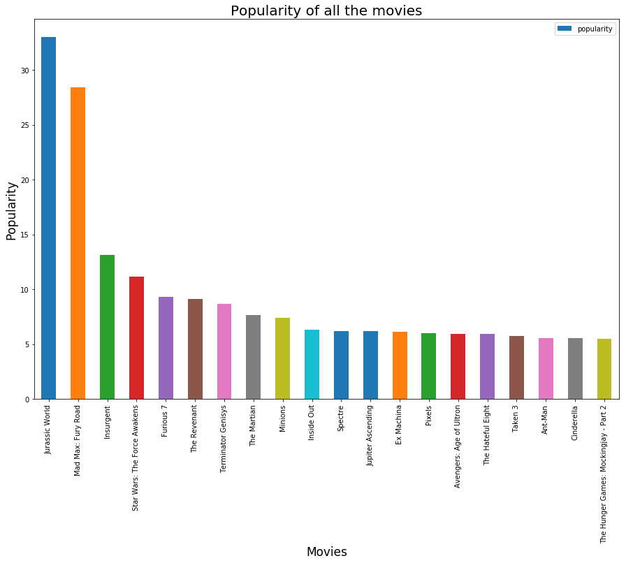

```python
#ploting the most popular movies using bar graph..
pop=new_data[0:20]
pop.plot(x='original_title',y='popularity',kind='bar',figsize=(15,10))
mlt.xlabel('Movies', fontsize = 17)
mlt.ylabel('Popularity', fontsize=17)
mlt.title('Popularity of all the movies', fontsize=20);
```

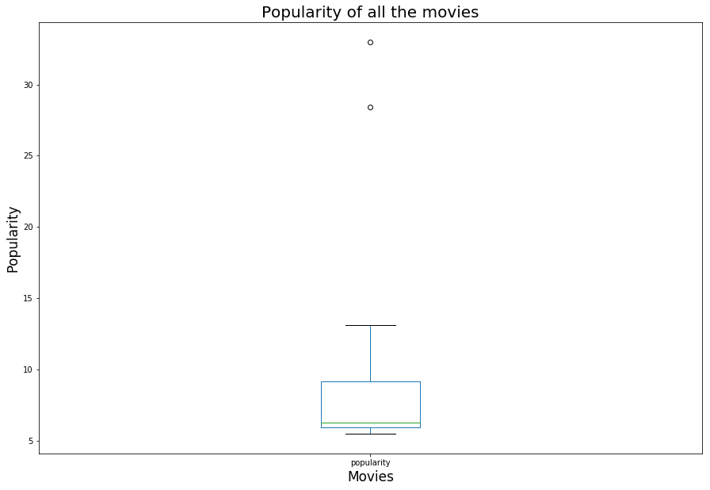

```python
pop=new_data[0:20]
pop.plot(x='original_title',y='popularity',kind='box',figsize=(15,10))
mlt.xlabel('Movies', fontsize = 17)
mlt.ylabel('Popularity', fontsize=17)
mlt.title('Popularity of all the movies', fontsize=20);
```

### Research Question 2 (Ploting the graph of Year of Release Vs Profitability)

```python
#finding the profit by subtracting revenue and budget..
new_data.insert(5,'profit',new_data['revenue']-new_data['budget'])
new_data.head(2)
```

|  | id | popularity | budget | revenue | original_title | profit | runtime | genres | release_date | vote_count | vote_average | release_year |
| --- | --- | --- | --- | --- | --- | --- | --- | --- | --- | --- | --- | --- |
| 0 | 135397 | 32.985763 | 150000000.0 | 1.513529e+09 | Jurassic World | 1.363529e+09 | 124 | Action\|Adventure\|Science Fiction\|Thriller | 2015-06-09 | 5562 | 6.5 | 2015 |
| 1 | 76341 | 28.419936 | 150000000.0 | 3.784364e+08 | Mad Max: Fury Road | 2.284364e+08 | 120 | Action\|Adventure\|Science Fiction\|Thriller | 2015-05-13 | 6185 | 7.1 | 2015 |

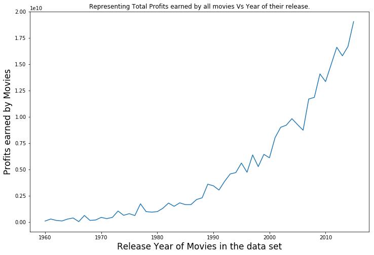

```python
profityear = new_data.groupby('release_year')['profit'].sum()
#figure size(width, height)
mlt.figure(figsize=(12,8))
#on x-axis
mlt.xlabel('Release Year of Movies in the data set', fontsize = 17)
#on y-axis
mlt.ylabel('Profits earned by Movies', fontsize = 17)
#title of the line plot
mlt.title('Representing Total Profits earned by all movies Vs Year of their release.')

#plotting the graph
mlt.plot(profityear)

#displaying the line plot
mlt.show()
```

### Research Question 3(To Find The Average Runtime Of The Movies)

```python
#finding the mean runtime.
new_data['runtime'].mean()
```

```
109.22029060716139
```

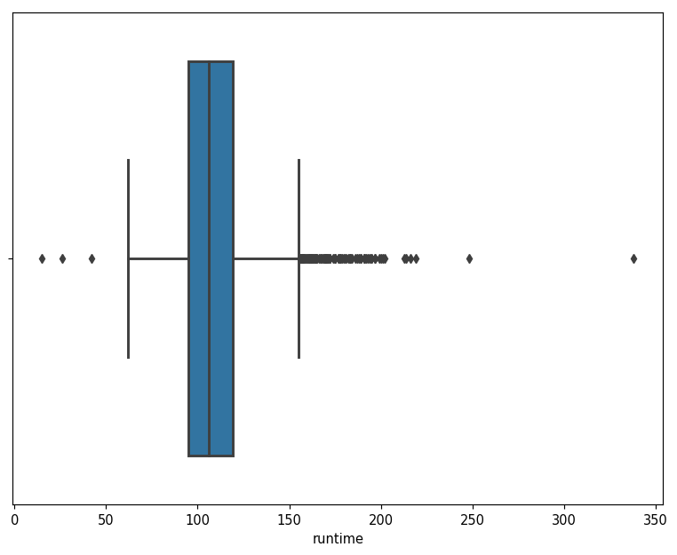

```python
import seaborn as sb
mlt.figure(figsize=(9,7), dpi = 105)
sb.boxplot(new_data['runtime'], linewidth = 2);
mlt.show()
```

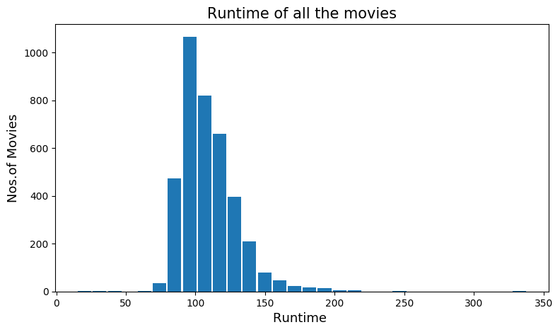

```python
#plotting a histogram of runtime of movies
mlt.figure(figsize=(9,5), dpi = 100)

#On x-axis
mlt.xlabel('Runtime ', fontsize = 13)
#On y-axis
mlt.ylabel('Nos.of Movies', fontsize=13)
#Name of the graph
mlt.title('Runtime of all the movies', fontsize=15)

#giving a histogram plot
mlt.hist(new_data['runtime'], rwidth = 0.9, bins =30)
#displays the plot
mlt.show()
```

```python
#calculating the no of movies released every year..
movies = df.groupby('release_year').count()['id']
movies.head()
```

```
release_year
1960     5
1961    10
1962     7
1963     6
1964     7
Name: id, dtype: int64
```

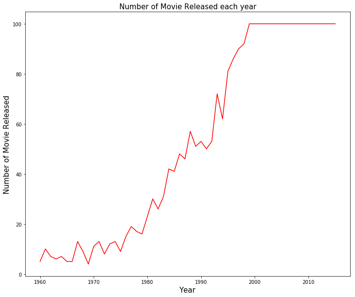

```python
#x-axis.
x = movies.index
#y-axis.
y = movies
mlt.figure(figsize=(12, 10))
mlt.plot(x, y, color = 'r')
mlt.title('Number of Movie Released each year',fontsize=15)
mlt.xlabel('Year',fontsize=15)
mlt.ylabel('Number of Movie Released',fontsize=15);
```

## Limitations

> 1.In my analysis I have removed many columns from the data which according to me was not useful for my analysis but those might be useful in some analysis process.  
> 2.I haven't removed the null values from the genres column. That might affect some results in my analysis. I could have searched the genres of those movies from google.  
> 3.Here,I are not sure if the data provided to us is completely corect and up-to-date.  
> 4.I have just assumed that the budget and revenue of the movies are in dollar, it might be possible that different movies have budget in different currency according to the country they are produce in.In that case the analysis would be incorrect.

```python
from subprocess import call
call(['python', '-m', 'nbconvert', 'Investigate_a_Dataset.ipynb'])
```

```
0
```